# assignment03 Yifan Qu 820266947

```r
library(tidyverse)
library(haven)
options(scipen = 999)
```

```r
school2018 <- read_sas("schools.sas7bdat")
school1 <- select(.data=school2018,unitid,state_cd,sector_cd,EFMaleCount,EFFemaleCount,EFTotalCount,TOTAL_EXPENSE_ALL,TOTAL_REVENUE_ALL,Sports)
sports <- count(school1,Sports)
sports <- filter(sports,n>1200)
```

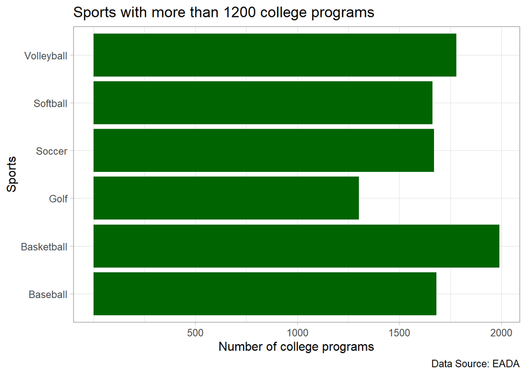

```r
ggplot(sports,mapping = aes(Sports,n))+
  geom_col(fill="darkgreen")+
  coord_flip()+
  ylab("Number of college programs")+
  theme_light(base_size = 12)+
  ggtitle("Sports with more than 1200 college programs")+
  labs(caption = "Data Source: EADA")+
  scale_y_continuous(breaks = c(500,1000,1500,2000) )
```

#This picture illustrates sports with the largest number of college athletic programs in the state.This includes:Basketball,Volleyball,Baseball,Softball,Soccer,and Golf.The number of college athletic programs in each of these sports exceeds 1,200. Obviously, these sports are popular and well developed by colleges.

```r
state <- count(school1,state_cd)
arrange(.data = state, desc(n))
```

```
## # A tibble: 55 x 2
##    state_cd     n
##    <chr>    <int>
##  1 CA        1633
##  2 NY        1442
##  3 PA        1308
##  4 TX         754
##  5 IL         740
##  6 MA         670
##  7 OH         640
##  8 NC         546
##  9 MI         494
## 10 FL         486
## # ... with 45 more rows
```

```r
state2 <- school1[which(school1$state_cd%in% c('CA')), ]
state2 <- mutate(state2,TOTAL_EXPENSE=TOTAL_EXPENSE_ALL/1000,TOTAL_REVENUE=TOTAL_REVENUE_ALL/1000)
view(state2)
```

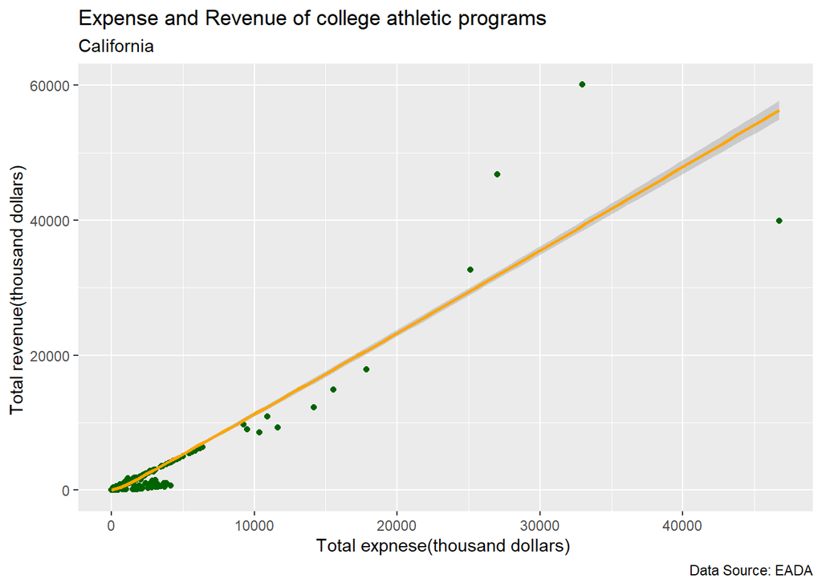

```r
ggplot(data = state2, mapping = aes(x = TOTAL_EXPENSE, y = TOTAL_REVENUE)) +
  geom_point(color = "darkgreen") +
  geom_smooth(color="orange")+
  ylab("Total revenue(thousand dollars) ")+
  xlab("Total expnese(thousand dollars) ")+
  ggtitle("Expense and Revenue of college athletic programs",subtitle = "California")+
  labs(caption = "Data Source: EADA")
```

#This picture uses California as an example to describe the relationship between revenue and expense of college athletic program. According to the fitted curve,expense and revenue are positively correlated.Also,the slope of the fitted curve is higher than 1.The higher the expense, the higher the average revenue.Policy support for the expansion of propahse expense will help the program’s sustainable development.

```r
sailing <- filter(school1,Sports == 'Sailing')
sailing <- rename(sailing,female = EFFemaleCount,male = EFMaleCount)
sailing2 <- select(sailing,state_cd,female,male)
sailing3<-sailing2%>%
  group_by(state_cd)%>%
  summarize(Female=sum(female),Male=sum(male))

sailing3 <- pivot_longer(sailing3,cols = c(-state_cd), names_to = "gender", values_to = "count")
```

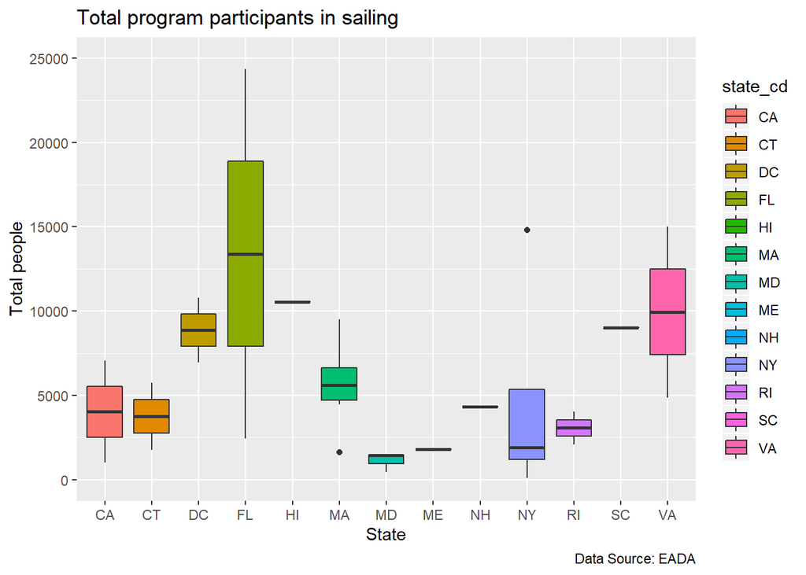

```r
ggplot(sailing,aes(x=state_cd, y=EFTotalCount,fill=state_cd))+
  geom_boxplot()+
  xlab("State")+
  ylab("Total people")+
  ggtitle("Total program participants in sailing")+
  labs(caption = "Data Source: EADA")+
  scale_y_continuous(limits = c(0,25000))
```

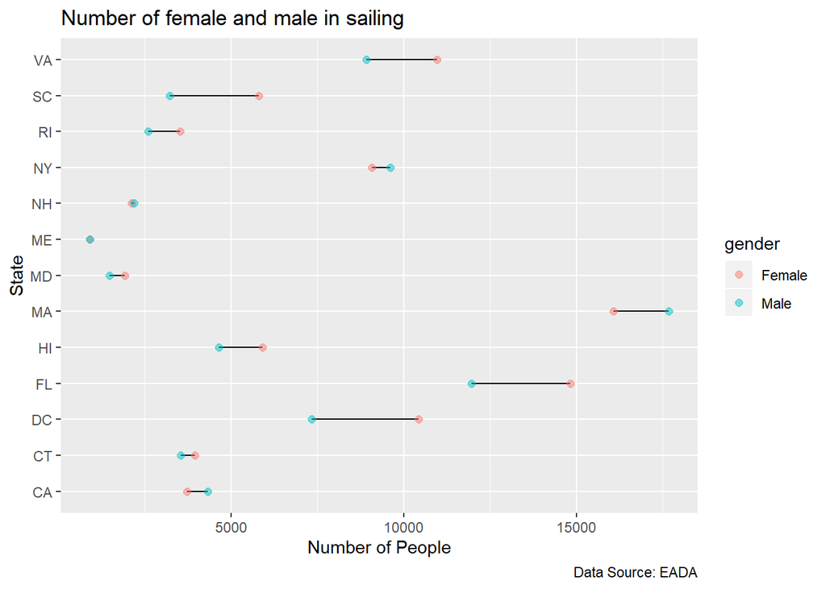

```r
ggplot(sailing3,) +
  geom_line(aes( x=state_cd,y =count))+
  geom_point(aes( x=state_cd,y =count,color = gender), size=2,alpha=0.5) +
  coord_flip()+
  xlab("State") +
  ylab("Number of People")+
  ggtitle("Number of female and male in sailing")+
  labs(caption = "Data Source: EADA")
```

#This picture depicts gender differences in participants of sailing.Participants in this sport have large gender differences in VA,SC,MA,HI,FL,and DC.Also, there are more female participants in sailing.Exploring the reasons for this may help the development of college sailing programs.